# Обзор методов доступа к файлам

дисциплина Операционные системы

Баранова А. А.

Российский университет дружбы народов, Москва, Россия

Кулябов Д. С. - д.ф.-м.н., профессор

20 февраля 2025

# Информация

## Докладчик

- Баранова Анна Андреевна
- Студент группы НММбд-01-24
- Российский университет дружбы народов
- 1132246811@pfur.ru

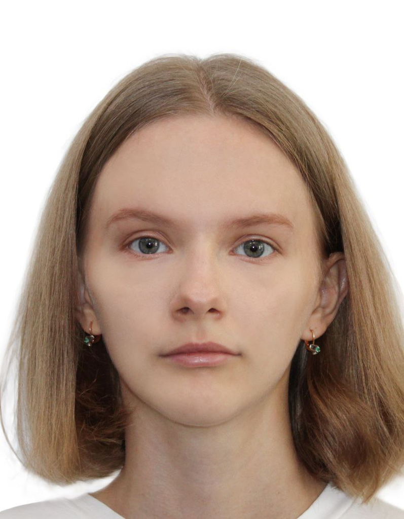

# Вводная часть

## Цели и задачи

- Изучить основные методы доступа к файлам
- Сравнить методы доступа
- Изучить современные тенденции

## Почему важно понимать методы доступа?

- Оптимизация производительности и эффективное использование ресурсов
- Безопасность данных
- Лучшая читаемость и поддерживаемость кода

[figure not shown]

# Методы доступа к файлу

## Последовательный доступ (Sequential Access)

- Данные читаются/записываются последовательно, начиная с начала файла
- **Преимущества:** Простота, эффективен для больших файлов при последовательной обработке
- **Недостатки:** Низкая скорость доступа к конкретной записи, не подходит для произвольного доступа

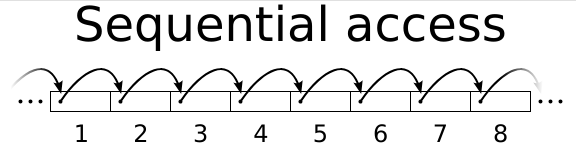

## Прямой/Произвольный доступ (Direct/Random Access)

- Программа может получить доступ к любой записи напрямую, зная её положение
- **Преимущества:** Высокая скорость доступа к любой записи, подходит для произвольного доступа
- **Недостатки:** Требует знания положения записи, записи должны быть одинаковой длины, сложнее в реализации

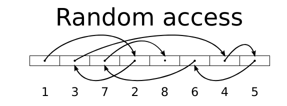

## Индексированный доступ (Indexed Access)

- Использует индекс для быстрого поиска записей в файле
- **Преимущества:** Высокая скорость поиска по ключу, обеспечивает произвольный доступ, гибкость
- **Недостатки:** Требует дополнительного места для хранения индекса, более сложный в реализации и управлении

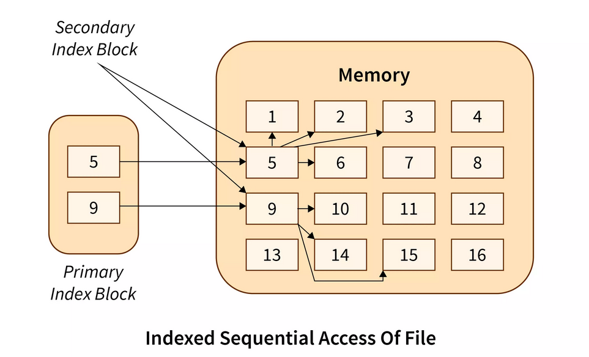

## Сравнение методов доступа

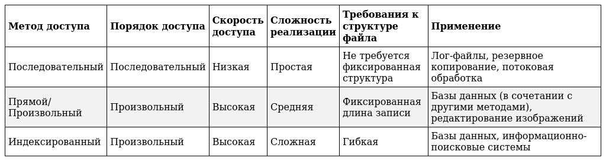

## Факторы, влияющие на выбор

- Размер файла
- Необходимость произвольного доступа и его скорость
- Сложность реализации
- Требования к обновлению данных

## Современные тенденции

- Объектно-ориентированный доступ к файлам
- Использование баз данных
- Облачные хранилища данных

[figure not shown]

# Заключение

## Краткие выводы

- Правильный выбор метода доступа – важный аспект разработки ПО
- Понимание преимуществ и недостатков – залог эффективных и производительных приложений
- Оптимальный выбор зависит от требований проекта и компромисса между скоростью, сложностью и гибкостью